# Regression

Week 7

Published

October 31, 2025

# Before we start

- Any questions?

[Download script](https://artur-baranov.github.io/nu-ps403-ds/scripts/ps403-d_07.qmd)

[Download data](https://artur-baranov.github.io/nu-ps403-ds/data/sipri.csv)

**Review**

If you have checked out the GitHub practice .qmd, then this would be quite familiar. Though, with the generated data! Let’s compare Histograms and Boxplots.

First of all, load `tidyverse` and `patchwork` libraries (intall the latter, if haven’t done so yet!).

```r
library(tidyverse)
library(patchwork)
```

Let’s generate the data. Say, coming from normal distribution. What is `rnorm`? Generate 1000 observaitons with $\mu = 0.5$ and $\sigma = 0.15$.

```r
set.seed(123)
data = data.frame(loyalty = rnorm(...))
```

Plot histogram first, then add a `geom_density()` layer. Customize the plot. Add limits for X axis on the graph from 0 to 1 using `xlim()`, change theme to `theme_minimal()`. Make sure to indicate median.

```r
gr_histogram = data %>%
  ggplot() +
    ...(aes(x = loyalty, y = ..density..), fill = "lightgray", color = "gray") +
    ...(aes(x = loyalty)) +
    ...
    ...
    labs(x = "Loyalty",
         y = "Density") +
   geom_vline(xintercept = median(data$loyalty), size = 1)

gr_histogram
```

Now, repeat the same process with boxplot. Make loyalty appear on the Y axis. Add `coord_flip()`.

```r
gr_boxplot = data %>%
  ggplot(aes(x = "", y = loyalty)) +
    geom_boxplot(fill = "lightgray") +
    ...
    theme_minimal() +
    labs(x = "", y = "Loyalty") +
    ylim(0,1)

gr_boxplot
```

Finally, compare them together. We can use `patchwork` for this. Compare the graphs.

```r
gr_histogram / gr_boxplot
```

# Agenda

- Practice joins (again!)
- Build OLS Regression Models (with extensions!)
- Presenting Regression Results

# Exploring the Data

We are working with V-Dem and [SIPRI Arms Transfers Database](https://www.sipri.org/databases/armstransfers). It contains information on all transfers of major conventional arms. The variables are:

- `Recipient` of arms
- `Year` of the transfer
- `Import` of arms
- `Regime` a V-Dem variable for political regime

```r
sipri = read.csv("data/sipri.csv")
```

Now, subset some variables from V-Dem. We are choosing the following variables:

- `country_name`
- `year` of the coded data
- `e_gdp` GDP of a country
- `e_miinteco` Armed conflict, international
- `e_miinterc` Armed conflict, internal

```r
load(url("https://github.com/vdeminstitute/vdemdata/raw/6bee8e170578fe8ccdc1414ae239c5e870996bc0/data/vdem.RData"))
vdem_variables = vdem %>%
  select(country_name, year, e_gdp, e_miinteco, e_miinterc)
```

Note the syntax below. We are joining two dataframes by two variables: `Recipient` and `Year`, but in the V-Dem data those have different name or spelling.

```r
sipri_vdem = sipri %>%
  left_join(vdem_variables, by = c("Recipient" = "country_name",
                                   "Year" = "year"))

head(sipri_vdem)
```

```
  Recipient Year Import                  Regime    e_gdp e_miinteco e_miinterc
1     India 1950    141              Autocratic 42170.12          0          0
2     India 1951    277 Electoral Authoritarian 42010.81          0          0
3     India 1952    104    Minimally Democratic 43033.76          0          0
4     India 1953    430    Minimally Democratic 44503.00          0          0
5     India 1954    265    Minimally Democratic 45960.55          0          0
6     India 1955    350    Minimally Democratic 47305.30          1          1
```

For our convenience, rename the variables in the newly created dataframe.

```r
sipri_vdem = sipri_vdem %>%
  rename(GDP = e_gdp,
         International_conflict = e_miinteco,
         Internal_conflict = e_miinterc)

head(sipri_vdem)
```

```
  Recipient Year Import                  Regime      GDP International_conflict
1     India 1950    141              Autocratic 42170.12                      0
2     India 1951    277 Electoral Authoritarian 42010.81                      0
3     India 1952    104    Minimally Democratic 43033.76                      0
4     India 1953    430    Minimally Democratic 44503.00                      0
5     India 1954    265    Minimally Democratic 45960.55                      0
6     India 1955    350    Minimally Democratic 47305.30                      1
  Internal_conflict
1                 0
2                 0
3                 0
4                 0
5                 0
6                 1
```

Explore the `GDP` variable. What can you notice? Take the `log()` of GDP directly in the plot. Did it get better?

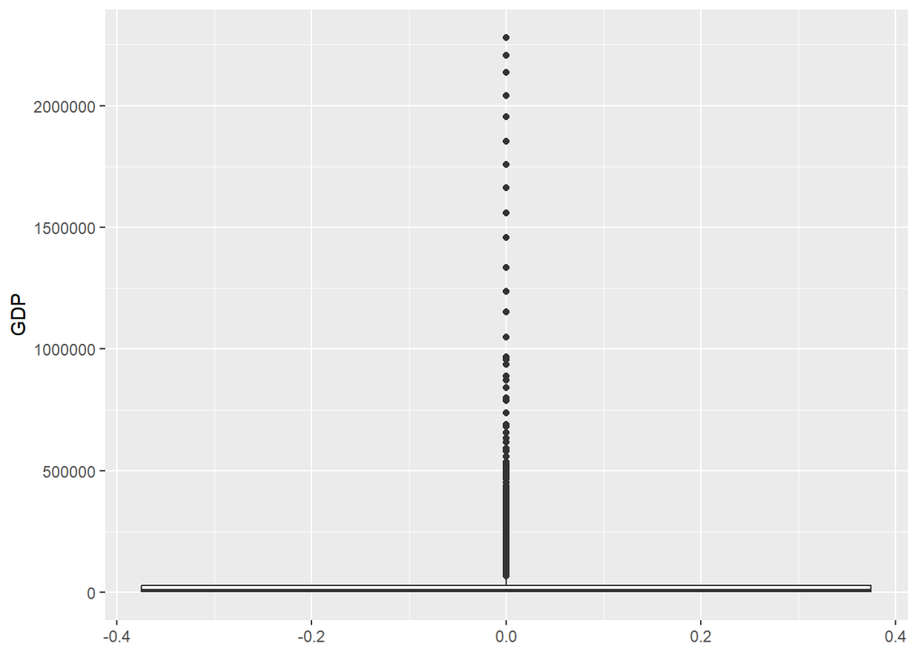

```r
ggplot(sipri_vdem) +
  geom_boxplot(aes(y = GDP))
```

Therefore, let’s create a new variable `Log_GDP`. This is a very typical operation. We call it transformations.

```r
sipri_vdem = sipri_vdem %>%
  mutate(Log_GDP = log(GDP))
```

To explore multiple variables at once, it is useful to plot them in `pairs` plot. There’s a library `GGally` which is based on `ggplot2`, and it’s quite straightforward. Be careful with the wrong class identification! Can you notice anything?

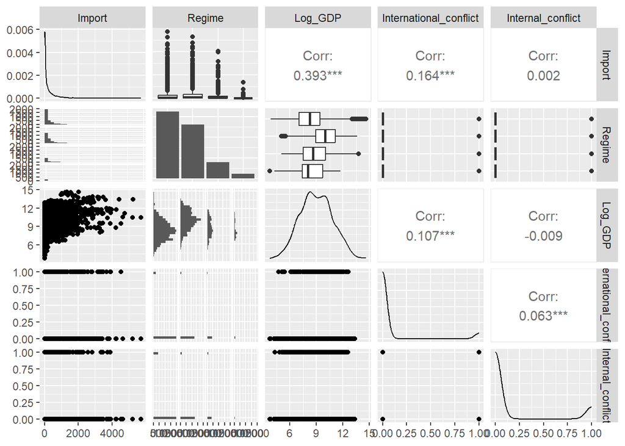

```r
library(GGally)

sipri_vdem %>%
  ggpairs(columns = c("Import", "Regime", "Log_GDP", "International_conflict", "Internal_conflict"))
```

Don’t forget to fix the classes of the variables!

```r
sipri_vdem$International_conflict = as.factor(sipri_vdem$International_conflict)
sipri_vdem$Regime = as.factor(sipri_vdem$Regime)
```

# Model Building

Let’s set up a basic model. We are interested in explaining the `Import` of arms. Is it related to the economic capacity of the state? We can use proxy `Log_GDP`. We can interpret and plot it quite easily, right? But does the intercept make sense?

```r
model_basic = lm(Import ~ Log_GDP, sipri_vdem)
summary(model_basic)
```

```
Call:
lm(formula = Import ~ Log_GDP, data = sipri_vdem)

Residuals:
   Min     1Q Median     3Q    Max
-676.3 -222.9  -87.5   66.0 5291.1

Coefficients:
            Estimate Std. Error t value Pr(>|t|)
(Intercept) -718.034     29.032  -24.73   <2e-16 ***
Log_GDP      108.547      3.168   34.26   <2e-16 ***
---
Signif. codes:  0 '***' 0.001 '**' 0.01 '*' 0.05 '.' 0.1 ' ' 1

Residual standard error: 457.9 on 6439 degrees of freedom
  (436 observations deleted due to missingness)
Multiple R-squared:  0.1542,    Adjusted R-squared:  0.1541
F-statistic:  1174 on 1 and 6439 DF,  p-value: < 2.2e-16
```

However, simple models are rare to see in academic articles. Let’s run a Multiple Linear Regression with fixed effects. Add `International_conflict` and `Regime` to the model. You can interpret these coefficients easily, too.

```r
model_fe = lm(Import ~ Log_GDP + International_conflict + Regime, sipri_vdem)
summary(model_fe)
```

```
Call:
lm(formula = Import ~ Log_GDP + International_conflict + Regime,
    data = sipri_vdem)

Residuals:
   Min     1Q Median     3Q    Max
-991.3 -217.9  -82.6   81.4 5169.6

Coefficients:
                              Estimate Std. Error t value Pr(>|t|)
(Intercept)                   -783.055     36.852 -21.248  < 2e-16 ***
Log_GDP                        126.364      4.468  28.281  < 2e-16 ***
International_conflict1        206.923     26.470   7.817 6.72e-15 ***
RegimeDemocratic               -95.328     17.191  -5.545 3.11e-08 ***
RegimeElectoral Authoritarian -151.434     23.328  -6.491 9.45e-11 ***
RegimeMinimally Democratic    -216.183     50.820  -4.254 2.15e-05 ***
---
Signif. codes:  0 '***' 0.001 '**' 0.01 '*' 0.05 '.' 0.1 ' ' 1

Residual standard error: 454.6 on 4347 degrees of freedom
  (2524 observations deleted due to missingness)
Multiple R-squared:  0.1995,    Adjusted R-squared:  0.1986
F-statistic: 216.6 on 5 and 4347 DF,  p-value: < 2.2e-16
```

To convey a better idea what’s going on, you can plot these three independent variables. We can use `marginaleffects` library for this.

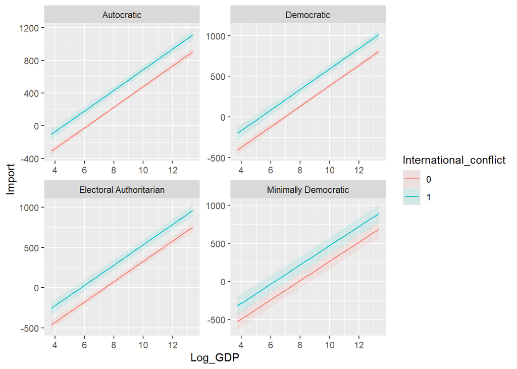

```r
library(marginaleffects)

model_fe %>%
  plot_predictions(condition  = c("Log_GDP", "International_conflict", "Regime"))
```

Finally, let’s set up another model. This time with an interaction effect. Again, to get a better idea what’s going on, you can plot the three independent variables against the dependent variable. But the limitation is it’s hard to include more variables into the graph.

However, good news is that it is still a `ggplot` object! So you can customize it in a same manner.

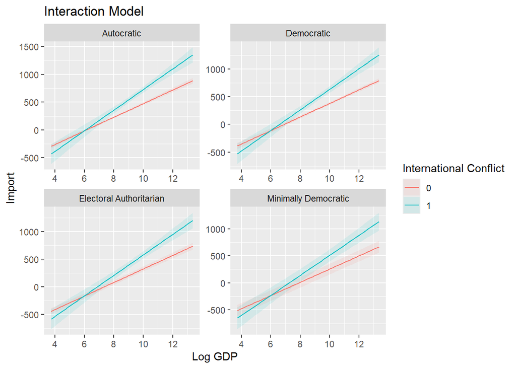

```r
model_int = lm(Import ~ Log_GDP * International_conflict + Regime, sipri_vdem)

model_int %>%
    plot_predictions(condition  = c("Log_GDP", "International_conflict", "Regime")) +
    labs(x = "Log GDP",
         y = "Import",
         title = "Interaction Model",
         color = "International Conflict",
         fill = "International Conflict")
```

# Presentation of Results with Tables

The most common way to present the resutls of the regression is in tables. We have practiced it over the last two quarters. By now, the expectation is you know how to present models in a “publishable” way. For details and examples see [details](https://modelsummary.com/vignettes/modelsummary.html).

Don’t forget to:

- Include p-values and $\alpha$ (critical values for stars display)!
- Or include confidence intervals for $\beta$ (`statisitc = "conf.int")`
- If you have a categorical variable, mention the reference category
- $R^2$ for simple linear regression and $R^2_a$ for multiple linear regression
- Include number of observations
- Be concise (unless it’s made for appendix)! You can simply highlight you have fixed effects instead of including the coefficient.

Add the following argument: `output = "table.html"` if you want to save the table.

```r
library(modelsummary)
publishable_table = modelsummary(list("Base model" = model_basic,
                    "Fixed Effects model" = model_fe,
                    "Interaction model" = model_int),
                   title = "Arms Import Models",
                   stars = c("*" = 0.05), # or TRUE for default settings
                   gof_omit = "AIC|BIC|Log.Lik|F|RMSE",
                   coef_rename = c("(Intercept)",
                             "Log GDP",
                             "International Conflict",
                             "Regime: Democratic",
                             "Regime: Electoral Authoritarian",
                             "Regime: Minimally Democratic",
                             "Log GDP × International Conflict"),
                   notes = "Regime reference category: Autocratic",
                   statistic = c("p.value"))

publishable_table
```

Arms Import Models

|  | Base model | Fixed Effects model | Interaction model |
| --- | --- | --- | --- |
| (Intercept) | -718.034* | -783.055* | -747.804* |
|  | (<0.001) | (<0.001) | (<0.001) |
| Log GDP | 108.547* | 126.364* | 122.263* |
|  | (<0.001) | (<0.001) | (<0.001) |
| International Conflict |  | 206.923* | -375.723* |
|  |  | (<0.001) | (0.013) |
| Regime: Democratic |  | -95.328* | -95.161* |
|  |  | (<0.001) | (<0.001) |
| Regime: Electoral Authoritarian |  | -151.434* | -151.842* |
|  |  | (<0.001) | (<0.001) |
| Regime: Minimally Democratic |  | -216.183* | -218.460* |
|  |  | (<0.001) | (<0.001) |
| Log GDP × International Conflict |  |  | 63.002* |
|  |  |  | (<0.001) |
| Num.Obs. | 6441 | 4353 | 4353 |
| R2 | 0.154 | 0.199 | 0.202 |
| R2 Adj. | 0.154 | 0.199 | 0.201 |

* p < 0.05  
Regime reference category: Autocratic

When you have fixed effects, it may be a good practice to eliminate fixed effects coefficients. For example,

```r
modelsummary(list("Base model" = model_basic,
                    "Fixed Effects model" = model_fe,
                    "Interaction model" = model_int),
                   title = "Arms Import Models",
                   stars = c("*" = 0.05),
                   gof_omit = "AIC|BIC|Log.Lik|F|RMSE",
                   coef_omit = "Regime", # remove the coefficient you do not need to show
                   coef_rename = c("(Intercept)",
                             "Log GDP",
                             "International Conflict",
                             "Log GDP × International Conflict"),
                  add_rows = data.frame(term = "Fixed effects",
                                   base = "-",
                                   fe = "+",
                                   int = "+"))
```

Arms Import Models

|  | Base model | Fixed Effects model | Interaction model |
| --- | --- | --- | --- |
| (Intercept) | -718.034* | -783.055* | -747.804* |
|  | (29.032) | (36.852) | (37.877) |
| Log GDP | 108.547* | 126.364* | 122.263* |
|  | (3.168) | (4.468) | (4.582) |
| International Conflict |  | 206.923* | -375.723* |
|  |  | (26.470) | (151.132) |
| Log GDP × International Conflict |  |  | 63.002* |
|  |  |  | (16.090) |
| Num.Obs. | 6441 | 4353 | 4353 |
| R2 | 0.154 | 0.199 | 0.202 |
| R2 Adj. | 0.154 | 0.199 | 0.201 |
| Fixed effects | - | + | + |

* p < 0.05

# Check List

- I am confident in my data merging skills
- I know how to use `GGally` to analyze pairs of variables
- I can plot complex models with `marginaleffects` library
- I know how to use `modelsummary()` to present publishable tables
- I have an intuition about predicted values and marginal effects
- I have an intuition about how to transform variables

# Optional Exercises

Let’s start with extracting the variables for the analysis. Select `country_name`, `year`, and Life expectancy (`e_pelifeex`) from vdem data.

**Solution**

```r
vdem_extraction = vdem %>%
  ...
```

Now, using `left_join()`, combine two dataframes: `sipri` and `vdem_extraction`.

**Solution**

```r
sipri_expectancy = sipri %>%
  ...(..., by = c("Recipient" = "country_name",
                                     "Year" = ...))
```

In the newly created `sipri_expectancy` dataframe, rename the `e_pelifeex` to `Life_expectancy`

**Solution**

```r
sipri_expectancy = ... %>%
  ...(Life_expectancy = ...)
```

Draw a `ggpairs()` graph (library is `GGally`). Can you discern any patterns (e.g., intersection of regime vs life expectancy or import vs life expectancy)?

**Solution**

YOUR SOLUTION HERE

Set up a fixed effects model. Regress `Import` against `Life_expectancy` and `Regime`

**Solution**

```r
life_expectancy_model_fe = lm(...)
```

Present a summary table

**Solution**

YOUR SOLUTION HERE

Present a `modelsummary()` table. Make it as publishable as possible. Don’t forget to include the reference category for the `Regime` variable.

**Solution**

YOUR SOLUTION HERE